[figure not shown]

[Escola de Verão 2025](http://les.uff.br/escola-de-verao)

Do início ao fim: limpeza, manipulação e modelagem

# Projeto: Análise espacial dos casos de dengue no Rio de Janeiro

## Download dos dados

Os dados utilizados neste projeto serão obtidos no DATASUS, do Ministério da Saúde, e no Instituto Brasileiro de Geografia e Estatística (IBGE).

### Dados territoriais

1. Os dados territoriais dos municípios do estado do Rio de Janeiro serão obtidos no site do IBGE, a partir dos [microdados do Censo Demográfico](https://www.ibge.gov.br/estatisticas/downloads-estatisticas.html).

Censos >> Censo_Demográfico_2010 >> Resultados_do_Universo >> Agregados_por_Setores_Censitários

As bases obtidas ao realizar o download apresentam as informações sobre o quantitativo de domicílios com determinada característica em cada setor censitário. Dessa maneira, é necessário construir os indicadores de interesse a partir dessas bases.

Por simplicidade, a base com os indicadores está disponível na pasta do repositório (*indicadores.xlsx*).

2. Os arquivos que contêm as delimitações dos municípios do estado do Rio de Janeiro podem ser acessados a partir das [malhas territoriais](https://www.ibge.gov.br/geociencias/organizacao-do-territorio/malhas-territoriais/15774-malhas.html) disponíveis no site do IBGE.

As bases com a malha territorial dos municípios do estado do Rio de Janeiro também estão disponíveis na pasta do GitHub (*RJ_Municipios*).

### Dados de dengue

Os dados sobre os casos notificados de dengue serão obtidos por meio do Sistema de Informação de Agravos de Notificação (SINAN) do DATASUS e serão baixados a partir do pacote `microdatasus`.

Caso não tenha o pacote `microdatasus` instalado, instale o pacote `remotes` para poder instalar o pacote `microdatasus`, seguindo os passos apresentados abaixo.

```r
# Instalar o pacote microdatasus
install.packages("remotes")
remotes::install_github("rfsaldanha/microdatasus")
```

Com o pacote instalado, é possível utilizar a função `fetch_datasus` para realizar o download da base nacional, indicando o período de análise a partir dos argumentos `year_start` (ano de início da análise) e `year_end` (último ano da análise). Como utilizaremos apenas o ano de 2024, `year_start = year_end = 2024`.

```r
# Carregar o pacote microdatasus
library(microdatasus)

# Baixar os dados do Brasil
dengue_BR <- fetch_datasus(year_start = 2024,
                           year_end = 2024,
                           information_system = "SINAN-DENGUE")
```

A base de dados das notificações de casos de dengue no Brasil em 2024 contém 6.453.004 registros (linhas) e 121 variáveis (colunas), caracterizando-se como uma base volumosa. Dependendo da configuração do computador, a manipulação desses dados pode ser desafiadora devido ao seu tamanho.

Como utilizaremos apenas os casos notificados nos municípios do estado do Rio de Janeiro, é necessário aplicar um filtro na variável `SG_UF_NOT` para selecionar apenas as notificações ocorridas nos municípios fluminenses. Esta variável contém os códigos de identificação das Unidades da Federação, conforme definidos pelo IBGE, sendo que o código do estado do Rio de Janeiro é *33*.

```r
# Carregar pacote para manipulação da base
library(tidyverse)

# Selecionar notificações no RJ
dengue_RJ <- dengue_BR |>
  filter(SG_UF_NOT == "33")
```

Agora, a base `dengue_RJ` contém 302.266 notificações (linhas) e 121 variáveis (colunas). A base está disponível no repositório, no arquivo *dengue_RJ_2024.csv*. A identificação das variáveis e os códigos de resposta podem ser consultados no arquivo *Ficha_SINAN_Dengue.pdf*, também disponível na pasta do repositório.

## Análise de Qualidade

Garantir que os dados tenham qualidade é essencial para a tomada de decisões assertivas e para o sucesso de projetos que dependem de grandes volumes de dados.

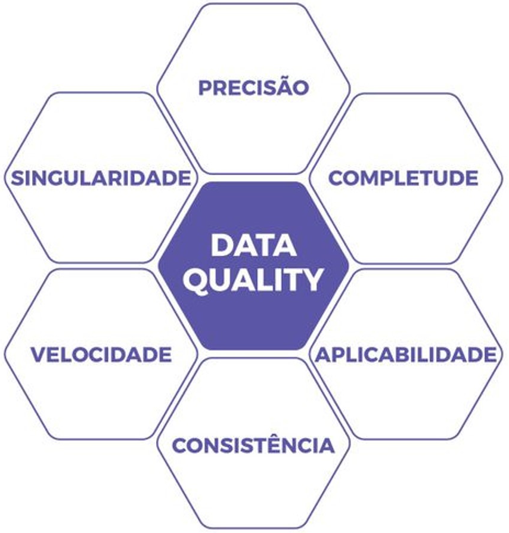

Os principais atributos de qualidade de dados incluem:

- **Precisão:** Toda informação deve descrever ou refletir o mundo real. Os dados precisam ser fiéis à realidade de acordo com as predefinições da estratégia e do processo de coleta.
- **Completude:** Os dados não podem estar fragmentados. Todas as informações essenciais devem ser adquiridas para garantir que o dado esteja completo.
- **Consistência:** Dados consistentes são aqueles que, quando comparados com outras fontes ou amostras, se confirmam e não apresentam discrepâncias inesperadas.
- **Velocidade:** Com que rapidez os dados são acessados? Em uma governança de dados eficiente, a agilidade na entrega das informações é essencial para a operação.
- **Singularidade:** Informações duplicadas podem resultar em erros críticos dentro de uma estratégia. Se os dados não forem únicos, as análises podem não refletir a realidade.
- **Aplicabilidade:** Os dados armazenados devem ser utilizáveis e relevantes para gerar insights e tomar decisões estratégicas.

Para avaliar a qualidade da base obtida no DATASUS, serão verificadas algumas características.

A **precisão** dos dados envolve a remoção de notificações em que há certeza de que não se trata de um caso de dengue. Os casos notificados são classificados em **casos confirmados** e **casos suspeitos** de dengue. Dessa forma, os **casos descartados** — aqueles nos quais há confirmação de que não se trata de dengue — devem ser excluídos da base de dados para garantir a qualidade da análise.

A variável `CLASSI_FIN` indica a **classificação final** da notificação após a investigação. Os valores que essa variável pode assumir estão descritos na tabela abaixo:

| Código | Classificação |
| --- | --- |
| 5 | Descartado |
| 8 | Ignorado |
| 10 | Dengue |
| 11 | Dengue com Sinais de Alarme |
| 12 | Dengue Grave |
| 13 | Chikungunya |

Portanto, ao analisar os valores presentes na variável `CLASSI_FIN`, podemos observar as seguintes classificações finais das notificações:

```r
# Contar os registros por classificação
table(dengue_RJ$CLASSI_FIN)
```

```
     8     10     11     12
 33601 262990   4980    268
```

Observe que não há registros de casos **descartados** nem de **chikungunya**. Portanto, todos os registros da base correspondem a casos **confirmados** ou **suspeitos** de dengue.

Observe abaixo que há 427 registros em que a variável `CLASSI_FIN` está sem informação. Estes registros também serão considerados na análise, pois não há evidências suficientes para descartá-los.

```r
# Contar as frequências de NA
table(is.na(dengue_RJ$CLASSI_FIN))
```

```
 FALSE   TRUE
301839    427
```

Para avaliar a **completude**, foram selecionadas as variáveis sociodemográficas, a data de notificação do caso, a data dos primeiros sintomas e a variável de classificação final.

```r
# Calcular a completude de cada variável (porcentagem de valores não NA)
completude <- dengue_RJ |>
  select(DT_NOTIFIC, DT_SIN_PRI, ANO_NASC, NU_IDADE_N,
         CS_SEXO, CS_GESTANT, CS_RACA, CS_ESCOL_N, CLASSI_FIN) |>
  summarise_all(~sum(!is.na(.)) / n()) |>
  pivot_longer(cols = everything(),
               names_to = "variavel",
               values_to = "completude")

# Multiplicar por 100 para obter a porcentagem
completude <- completude |>
  mutate(completude_percentual = round(completude * 100,1))

# Visualizar a base
completude
```

```
# A tibble: 9 × 3
  variavel   completude completude_percentual
  <chr>           <dbl>                 <dbl>
1 DT_NOTIFIC      1                     100
2 DT_SIN_PRI      1                     100
3 ANO_NASC        0.991                  99.1
4 NU_IDADE_N      1                     100
5 CS_SEXO         1.00                  100
6 CS_GESTANT      1.00                  100
7 CS_RACA         1.00                  100
8 CS_ESCOL_N      0.769                  76.9
9 CLASSI_FIN      0.999                  99.9
```

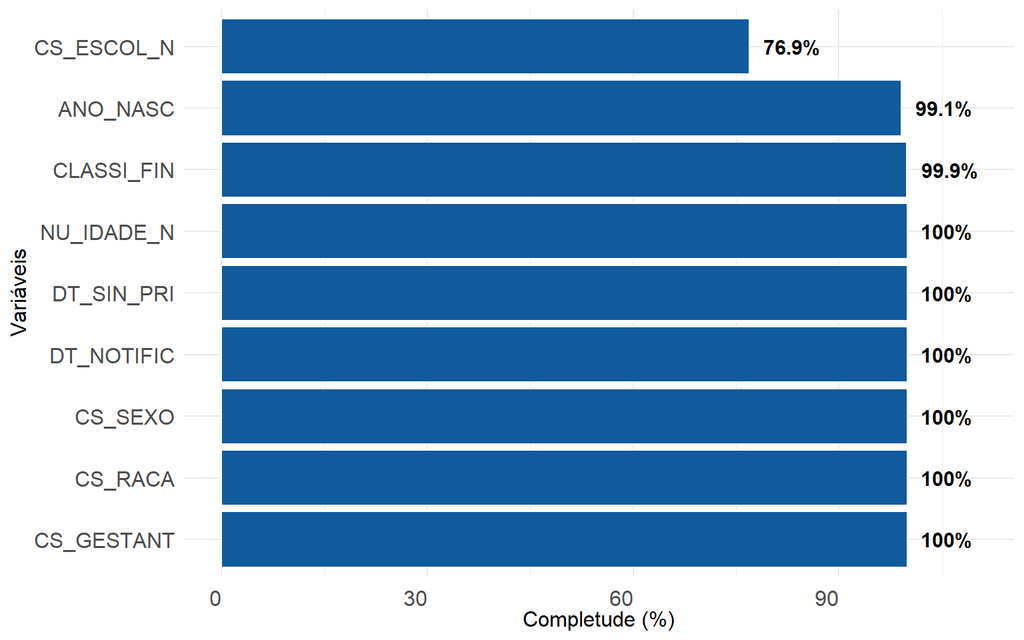

```r
# Criar gráfico de barras com ggplot2
ggplot(completude, aes(x = fct_reorder(variavel,
                                       completude_percentual,
                                       .desc = TRUE),
                       y = completude_percentual)) +
  geom_bar(stat = "identity", fill = "#115a9c", color = "white") +
  geom_text(aes(label = paste0(completude_percentual, "%")),
            hjust = -0.25, size = 4, fontface = "bold") +
  ylim(0, 110) +
  labs(x = "Variáveis",
       y = "Completude (%)") +
  coord_flip() +
  theme_minimal() +
  theme(axis.text.x = element_text(size = 12, hjust = 1, vjust = 0),
        axis.text.y = element_text(size = 12),
        axis.title = element_text(size = 12))
```

Suponha que o objetivo da sua análise seja avaliar os impactos de variáveis sociodemográficas no risco de dengue em cada município.

Se a variável `CS_ESCOL_N` tem uma alta porcentagem de não preenchimento, como poderemos utilizá-la?

Na verdade, não poderemos utilizá-la! Observe que a variável `CS_ESCOL_N` apresenta quase 1/4 de valores ausentes (`NA`), ou seja, das 302.226 notificações, em 69.864 não foi preenchida a informação sobre a escolaridade do paciente.

Caso o não preenchimento representasse uma parcela extremamente pequena, ainda assim precisaríamos avaliar o padrão dessa ausência de informação. Pense, por exemplo, que a variável apresenta 3% de valores ausentes (`NA`). A princípio, esse quantitativo pode parecer insignificante e poderíamos seguir com a análise ignorando esses dados faltantes. No entanto, se esses 3% estiverem concentrados em determinado município do estado do Rio de Janeiro, será que seria adequado descartá-los?

Abaixo, vamos avaliar como os valores ausentes das variáveis `CS_ESCOL_N` e `CLASSI_FIN` estão distribuídos pelos municípios do estado do Rio de Janeiro.

O primeiro passo é contar quantos valores ausentes (`NA`) existem na variável `CS_ESCOL_N` em cada município (a partir do código de identificação do município apresentado na variável `ID_MUNICIP`).

```r
# Calcular os valores ausentes de cada variável
n_NA <- dengue_RJ |>
  select(ID_MUNICIP, CS_ESCOL_N, CLASSI_FIN) |>
  group_by(ID_MUNICIP) |>
  summarise(across(everything(), ~ round(sum(is.na(.)) / n() * 100, 1),
                   .names = "perc_na_{.col}"))

head(n_NA)
```

```
# A tibble: 6 × 3
  ID_MUNICIP perc_na_CS_ESCOL_N perc_na_CLASSI_FIN
       <dbl>              <dbl>              <dbl>
1     330010               33.5                0.2
2     330015                7.8                3
3     330020               37.8                1.2
4     330022               63                  0
5     330023               30.6                0
6     330025               36.3                0.5
```

Perceba como alguns municípios apresentam porcentagens de valores ausentes maiores do que outros. É interessante, então, avaliar como essas taxas estão distribuídas espacialmente. Será que existe algum padrão?

É preciso, então, ler o arquivo com as delimitações dos 92 municípios do estado do Rio de Janeiro e construir mapas coropléticos para representar as taxas de valores ausentes das variáveis `CS_ESCOL_N` e `CLASSI_FIN`.

```r
# Carregar pacote
library(sf)

# Ler o arquivo shapefile com as delimitações
RJ <- read_sf("RJ_Municipios/RJ_Municipios.shp")
RJ
```

```
Simple feature collection with 92 features and 13 fields
Geometry type: MULTIPOLYGON
Dimension:     XY
Bounding box:  xmin: -44.88932 ymin: -23.36893 xmax: -40.95794 ymax: -20.76321
Geodetic CRS:  SIRGAS 2000
# A tibble: 92 × 14
   CD_MUN NM_MUN CD_RGI NM_RGI CD_RGINT NM_RGINT CD_UF NM_UF CD_REGIAO NM_REGIAO
   <chr>  <chr>  <chr>  <chr>  <chr>    <chr>    <chr> <chr> <chr>     <chr>
 1 33001… Angra… 330002 Angra… 3301     Rio de … 33    Rio … 3         Sudeste
 2 33001… Aperi… 330012 Santo… 3304     Campos … 33    Rio … 3         Sudeste
 3 33002… Araru… 330013 Cabo … 3305     Macaé -… 33    Rio … 3         Sudeste
 4 33002… Areal  330007 Petró… 3303     Petrópo… 33    Rio … 3         Sudeste
 5 33002… Armaç… 330013 Cabo … 3305     Macaé -… 33    Rio … 3         Sudeste
 6 33002… Arrai… 330013 Cabo … 3305     Macaé -… 33    Rio … 3         Sudeste
 7 33003… Barra… 330004 Volta… 3302     Volta R… 33    Rio … 3         Sudeste
 8 33004… Barra… 330004 Volta… 3302     Volta R… 33    Rio … 3         Sudeste
 9 33004… Belfo… 330001 Rio d… 3301     Rio de … 33    Rio … 3         Sudeste
10 33005… Bom J… 330008 Nova … 3303     Petrópo… 33    Rio … 3         Sudeste
# ℹ 82 more rows
# ℹ 4 more variables: CD_CONCURB <chr>, NM_CONCURB <chr>, AREA_KM2 <dbl>,
#   geometry <MULTIPOLYGON [°]>
```

```r
class(RJ)
```

```
[1] "sf"         "tbl_df"     "tbl"        "data.frame"
```

A base de dados `RJ` é um data frame espacial e possui as informações geométricas dos 92 municípios, além de outras informações, como o nome e o código do município.

É preciso então unir as informações das porcentagens de valores ausentes com a base `RJ`. No entanto, perceba que, na base `RJ`, a variável que identifica o município possui 7 dígitos, enquanto, na base com as porcentagens de valores ausentes, os códigos dos municípios estão representados com 6 dígitos. Neste caso, o último dígito da variável com 7 dígitos é dispensável.

Primeiro, recriaremos a variável de identificação do município com 6 dígitos na base `RJ` e, em seguida, uniremos as duas bases, sempre incorporando as variáveis à base `RJ` para garantir que a base final continuará sendo um data frame espacial.

```r
# Criar código de município com 6 dígitos
RJ <- RJ |>
  mutate(ID_MUNICIP = as.numeric(str_sub(CD_MUN, 1, 6)))

# Unir as bases
RJ <- RJ |>
  left_join(n_NA, by = "ID_MUNICIP")
```

Agora que a base está pronta, é possível construir os mapas coropléticos.

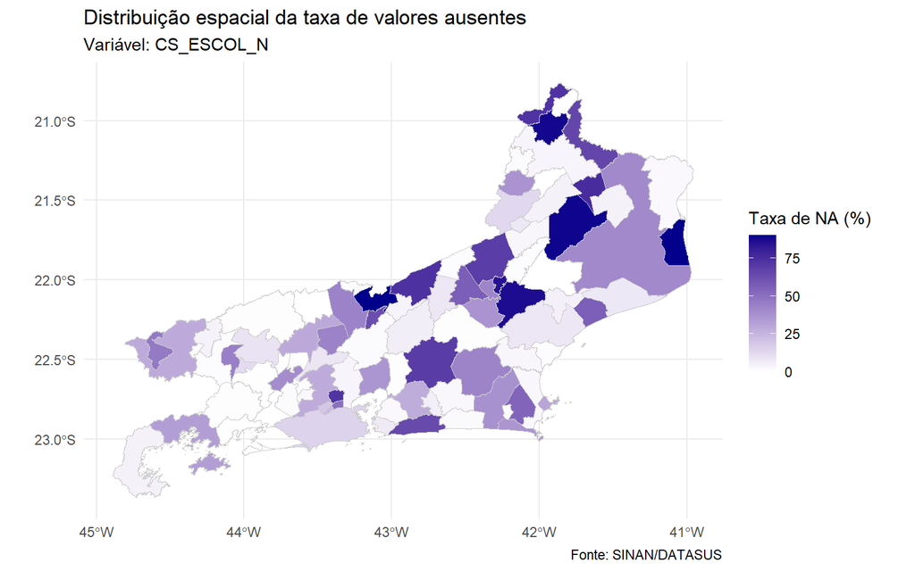

```r
# Criar o mapa coroplético para a variável CS_ESCOL_N
mapa_1 <- ggplot(RJ) +
  geom_sf(aes(fill = perc_na_CS_ESCOL_N), color = "gray80", size = 0.2) +
  scale_fill_gradient(low = "white", high = "darkblue", name = "Taxa de NA (%)")+
  labs(title = "Distribuição espacial da taxa de valores ausentes",
       subtitle = "Variável: CS_ESCOL_N",
       caption = "Fonte: SINAN/DATASUS") +
  theme_minimal()

# Apresentar o mapa
mapa_1
```

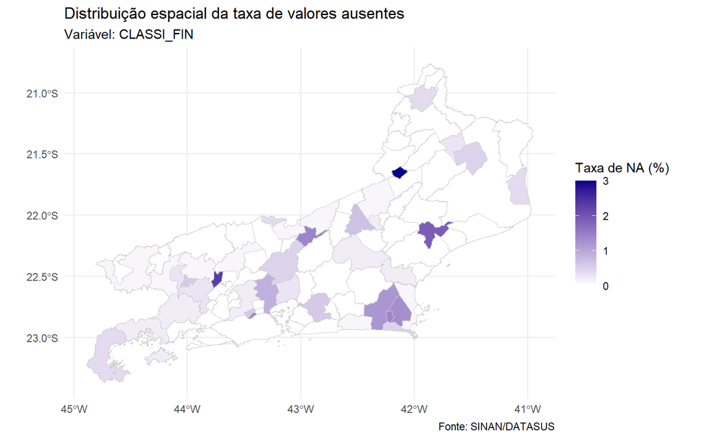

```r
# Criar o mapa coroplético para a variável CLASSI_FIN
mapa_2 <- ggplot(RJ) +
  geom_sf(aes(fill = perc_na_CLASSI_FIN), color = "gray80", size = 0.2) +
  scale_fill_gradient(low = "white", high = "darkblue", name = "Taxa de NA (%)")+
  labs(title = "Distribuição espacial da taxa de valores ausentes",
       subtitle = "Variável: CLASSI_FIN",
       caption = "Fonte: SINAN/DATASUS") +
  theme_minimal()

# Apresentar o mapa
mapa_2
```

Perceba que, em ambas as variáveis, a taxa de valores ausentes não é homogênea no espaço. Alguns municípios apresentam altas taxas, enquanto outros possuem taxas próximas a zero. Nesse caso, é possível identificar quais municípios apresentaram dificuldades no preenchimento dessas variáveis, o que pode indicar problemas específicos no processo de coleta de dados ou na qualidade das informações fornecidas.

A **duplicidade** de notificações também pode ser avaliada, uma vez que um mesmo indivíduo pode recorrer ao sistema de saúde diversas vezes para tratar dos sintomas. Nesse caso, esse indivíduo aparecerá mais de uma vez na base e precisará ser descartado.

Essa análise não é trivial, pois é difícil definir pacientes duplicados na base.  
A base não possui o nome do indivíduo nem seu endereço, o que facilitaria a identificação do paciente que aparece na base mais de uma vez.

Neste caso, trabalharemos com as variáveis disponíveis e indicaremos possíveis duplicações. Como não teremos certeza da duplicação, **não descartaremos** qualquer informação.

Esta análise servirá apenas para avaliar a **qualidade das informações** contidas na base.

Quais características podemos utilizar para tentar avaliar duplicidade?

Selecionaremos algumas variáveis para compor a análise de duplicidade:

- *DT_SIN_PRI:* data dos primeiros sintomas
- *ANO_NASC:* ano de nascimento
- *CS_SEXO:* sexo do paciente
- *CS_RACA:* raça do paciente
- *CS_GESTANT:* identificação se é gestante
- *CS_ESCOL_N:* escolaridade do paciente
- *ID_MN_RESI:* município de residência

```r
# Identificar as linhas duplicadas
duplicadas <- dengue_RJ |>
  distinct(DT_SIN_PRI, ANO_NASC, CS_SEXO, CS_RACA,
           CS_GESTANT, CS_ESCOL_N, ID_MN_RESI, .keep_all = TRUE)

# Contar possíveis duplicações
p <- round((dim(dengue_RJ)[1]-dim(duplicadas)[1])/dim(dengue_RJ)[1]*100,1)
p
```

```
[1] 11.9
```

Observe que 11,9% da base foi identificada como duplicada. Este número é extremamente alto e, possivelmente, esse resultado ocorreu porque não temos variáveis suficientes para caracterizar e identificar os indivíduos repetidos na base.

De maneira geral, a qualidade da base é satisfatória. Nenhum dado será descartado nas etapas de análise que serão realizadas a seguir.

## Manipulação e Análise Descritiva

A Análise Descritiva é uma etapa fundamental para compreender os padrões dos dados, as associações entre variáveis e fornecer embasamento para a escolha do método estatístico a ser aplicado.

No entanto, para realizar uma análise descritiva eficaz, é necessário manipular, harmonizar e estruturar adequadamente os dados.

Para isso, construiremos uma base única contendo todas as informações dos municípios, incluindo o número de casos de dengue, taxa de incidência, população e indicadores territoriais e sociodemográficos.

O primeiro passo é contar a quantidade de casos de dengue em cada município do estado do Rio de Janeiro no ano de 2024.

```r
# Contar casos de dengue por município
dengue <- dengue_RJ |>
  group_by(ID_MUNICIP) |>
  summarise(casos = n())
```

Agora, importaremos a base de indicadores calculados a partir dos dados do Censo Demográfico de 2010 e a estimativa da população em 2024, ambos disponibilizados pelo IBGE.

Os indicadores contidos na base são:

- *ind1:* percentual de domicílios conectados a rede geral de abastecimento de água.
- *ind2:* percentual de domicílios com abastecimento por poço, chuva armazenada em cisterna e outra forma de abastecimento.
- *ind3:* percentual de domicílios com banheiro de uso exclusivo conectado a rede geral de esgotamento sanitário ou fossa séptica.
- *ind4:* percentual de domicílios com banheiro de uso exclusivo e esgotamento sanitário via fossa rudimentar, vala, rio, lago, mar ou outro.
- *ind5:* percentual de domicílios com lixo coletado.
- *ind6:* percentual de domicílios com lixo jogado em terreno baldio, rio, lagoa, mar ou outro.
- *ind7:* percentual de domicílios com esgoto a céu aberto no entrono.
- *ind8:* percentual de domicílios sem bueiro no entorno.
- *ind9:* percentual de domicílios com lixo acumulado no entrono.
- *ind10:* percentual de domicílio com renda até 250 reais mensais per capta.
- *ind11:* índice de Gini 2010.
- *ind12:* IDHM 2010.
- *POP:* população residente estimada em 2024.

```r
# Carregar pacote
library(readxl)

# Importar a base com os indicadores
ind <- read_excel("indicadores.xlsx")
head(ind)
```

```
# A tibble: 6 × 17
  CD_GEOCODM ID_MUNICIP    UF NM_MUNICIP   ind1  ind2  ind3   ind4  ind5    ind6
       <dbl>      <dbl> <dbl> <chr>       <dbl> <dbl> <dbl>  <dbl> <dbl>   <dbl>
1    3300100     330010    33 ANGRA DOS … 0.889 0.111 0.854 0.144  0.989 4.60e-3
2    3300159     330015    33 APERIBÉ     0.866 0.134 0.786 0.213  0.877 2.61e-3
3    3300209     330020    33 ARARUAMA    0.891 0.109 0.648 0.348  0.936 4.72e-3
4    3300225     330022    33 AREAL       0.664 0.336 0.458 0.541  0.960 5.71e-4
5    3300233     330023    33 ARMAÇÃO DO… 0.803 0.197 0.901 0.0982 0.985 9.21e-3
6    3300258     330025    33 ARRAIAL DO… 0.690 0.310 0.916 0.0832 0.995 1.45e-3
# ℹ 7 more variables: ind7 <dbl>, ind8 <dbl>, ind9 <dbl>, ind10 <dbl>,
#   ind11 <dbl>, ind12 <dbl>, POP <dbl>
```

Observe que, agora, todas as informações estão na unidade de análise de município. Sendo assim, podemos unir todas as bases em uma única, contendo todas as informações necessárias.

Além disso, é possível calcular as taxas de incidência de casos de dengue por 100.000 habitantes em cada município da seguinte maneira:

$$\textrm{Taxa} = \dfrac{\textrm{casos de
dengue}}{\textrm{população}}\times 100.000$$

```r
# Unir todas as bases
base_RJ <- RJ |>
  left_join(dengue, by = "ID_MUNICIP") |>
  left_join(ind, by = "ID_MUNICIP") |>
  mutate(taxa = casos/POP*100000)
```

Com a base pronta, podemos iniciar as análises descritivas.

Inicialmente, iremos realizar uma análise empírica das correlações lineares entre as taxas de incidência de dengue e os indicadores territoriais e sociodemográficos.

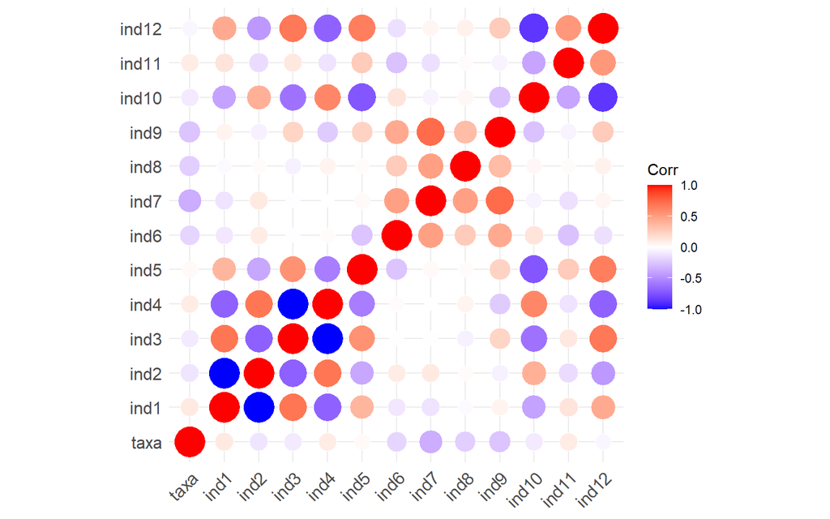

```r
# Carregar pacote
library(ggcorrplot)

# Construir o dataframe (retirar o geometry)
data <- st_drop_geometry(base_RJ[,c(35,22:33)])

# Calcular a matriz de correlação
matriz_cor <- cor(data)

# Criar a matriz de correlação
ggcorrplot(matriz_cor,
           method = "circle",
           type = "full",
           lab = FALSE,
           outline.color = "white",
           colors = c("blue", "white", "red"),
           ggtheme = theme_minimal())
```

Observe que as variáveis apresentam baixa correlação linear com a taxa de incidência, e alguns indicadores estão altamente correlacionados entre si. No entanto, é importante lembrar que a correlação linear tem limitações, pois não captura possíveis dinâmicas espaciais presentes nos dados.

Agora, vamos avaliar alguns indicadores e a taxa de incidência por meio de mapas coropléticos, com o objetivo de identificar possíveis padrões espaciais.

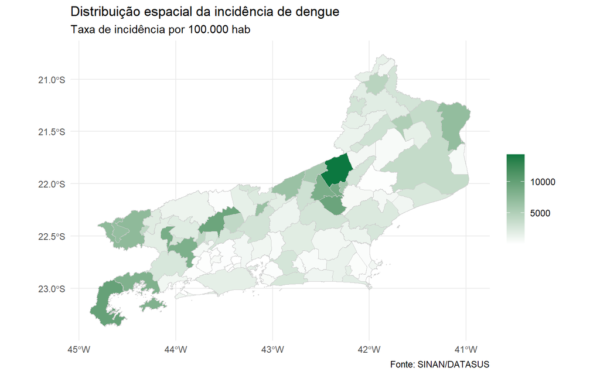

```r
# Criar o mapa coroplético da taxa de incidência
mapa_3 <- ggplot(base_RJ) +
  geom_sf(aes(fill = taxa), color = "gray80", size = 0.2) +
  scale_fill_gradient(low = "white", high = "#0c7840", name = "")+
  labs(title = "Distribuição espacial da incidência de dengue",
       subtitle = "Taxa de incidência por 100.000 hab",
       caption = "Fonte: SINAN/DATASUS") +
  theme_minimal()

# Apresentar o mapa
mapa_3
```

As maiores taxas de incidência estão concentradas nos municípios do Centro Fluminense e Sul Fluminense. O município de Cantagalo, localizado no Centro Fluminense, apresentou a maior taxa de incidência, com 14.332 casos de dengue a cada 100.000 habitantes.

Por outro lado, Nilópolis e Belford Roxo, ambos situados na Região Metropolitana, apresentaram as menores taxas de incidência, com 47 e 34 casos de dengue a cada 100.000 habitantes, respectivamente.

A análise de correlação revela que alguns indicadores estão fortemente correlacionados entre si. Para evitar colinearidade, selecionamos os indicadores: *ind1*, *ind3*, *ind7* e *ind10*. Vale destacar que esse tipo de seleção é subjetivo. O ideal seria utilizar métodos de seleção de variáveis para identificar aquelas que melhor explicam o desfecho de interesse.

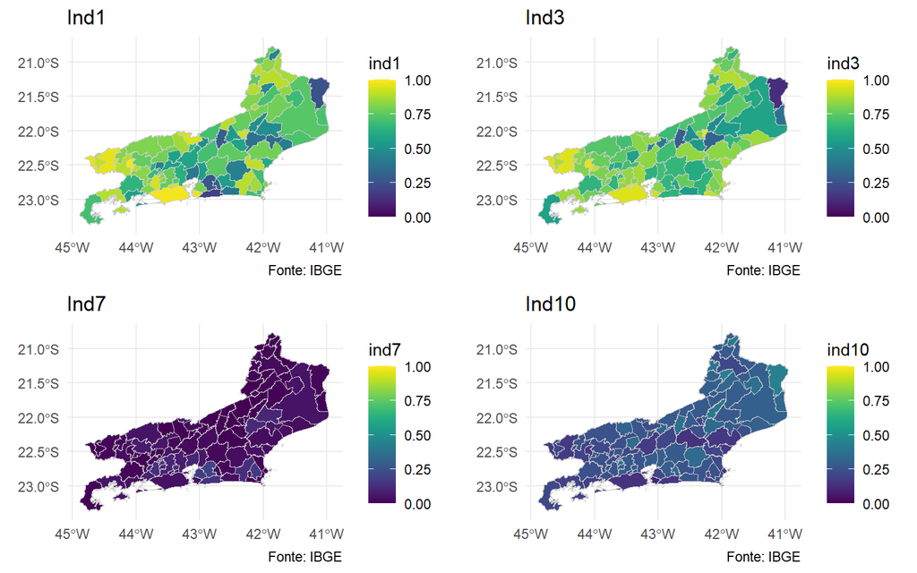

```r
# Criar o mapa coroplético do IND1
mapa_41 <- ggplot(base_RJ) +
  geom_sf(aes(fill = ind1), color = "gray80", size = 0.2) +
  scale_fill_viridis(limits = c(0, 1)) +
  labs(title = "Ind1",
       caption = "Fonte: IBGE") +
  theme_minimal()

# Criar o mapa coroplético do IND3
mapa_42 <- ggplot(base_RJ) +
  geom_sf(aes(fill = ind3), color = "gray80", size = 0.2) +
  scale_fill_viridis(limits = c(0, 1)) +
  labs(title = "Ind3",
       caption = "Fonte: IBGE") +
  theme_minimal()

# Criar o mapa coroplético do IND7
mapa_43 <- ggplot(base_RJ) +
  geom_sf(aes(fill = ind7), color = "gray80", size = 0.2) +
  scale_fill_viridis(limits = c(0, 1)) +
  labs(title = "Ind7",
       caption = "Fonte: IBGE") +
  theme_minimal()

# Criar o mapa coroplético do IND12
mapa_44 <- ggplot(base_RJ) +
  geom_sf(aes(fill = ind10), color = "gray80", size = 0.2) +
  scale_fill_viridis(limits = c(0, 1)) +
  labs(title = "Ind10",
       caption = "Fonte: IBGE") +
  theme_minimal()

gridExtra::grid.arrange(mapa_41,mapa_42,mapa_43,mapa_44, ncol = 2)
```

## Modelagem Estatística

Também estamos interessados em examinar a associação ecológica entre essas covariáveis e os casos de dengue nos municípios do estado do Rio de Janeiro. Para responder a essas questões, realizaremos o mapeamento da doença e a com INLA.

A análise de modelos estatísticos pode ser realizada de diversas maneiras. Geralmente, começamos com modelos mais simples e, gradualmente, aumentamos sua complexidade. A escolha do modelo mais adequado pode ser feita com base em alguma medida de comparação, definida conforme o objetivo da análise. Dessa forma, é possível avaliar qual modelo oferece o melhor desempenho.

Em todos os modelos avaliados, o interesse é representar o número de casos de dengue, $y_i$, no município $i$, $i=1,\ldots,N$. Uma estrutura simples de um Modelo Linear Generalizado pode ser descrita a partir do modelo $\textbf{M}_0$ abaixo
$$y_i \sim \text{Poisson}(\mu_i), \ \ i=1,\ldots,N \\
\log(\mu_i) = \log(E_i) + \beta_0 + \sum_{k=1}^K\beta_k \text{X}_{ik}\\
\beta_0,\beta_k \sim N(0,0.01), \ \ k=1,\ldots,K$$
Perceba que no modelo $\textbf{M}_0$ as observações são tratadas como independente. Para a relativização dos números de casos de dengue pela população residente nos municípios, foram utilizados termos de *offset* $\log(E_i)$, sendo que $E_i$ denota o número esperado de casos por município $i$, assumindo homogeneidade na distribuição de casos ao longo do estado.

A taxa estadual de casos por habitante foi multiplicada pelo tamanho da população residente de cada município:

$$E_{i} = \frac{\sum \text{casos de dengue}_{i}}{\sum
\text{população}_{i}} \times \text{população}_{i}$$
onde $E_{i}$ é o número esperado de casos por município.

Um segundo modelo que podemos avaliar, chamado de $\textbf{M}_1$, incorpora um efeito aleatório não estruturado no preditor para modelar a variabilidade não explicada pelas covariáveis, abordando um problema recorrente nesse tipo de modelo: a **sobredispersão**. Esse efeito aleatório permite capturar variações locais e erros não sistemáticos, conferindo maior flexibilidade ao modelo e melhorando sua capacidade de ajuste aos dados.

$$y_i \sim \text{Poisson}(\mu_i), \ \ i=1,\ldots,N \\
\log(\mu_i) = \log(E_i) + \beta_0 + \sum_{k=1}^K\beta_k \text{X}_{ik} +
u_i \\
u_i \sim N(0,\tau^2)\\
\tau \sim Gamma(1,0.01)\\
\beta_0,\beta_k \sim N(0,0.01), \ \ k=1,\ldots,K$$

Por último, descreveremos o terceiro modelo, $\textbf{M}_2$, que incorpora o efeito aleatório espacialmente estruturado para capturar a dependência espacial entre as unidades de observação. Esse modelo permite modelar a correlação espacial dos dados, considerando que as observações em localidades geográficas próximas tendem a ser mais semelhantes entre si do que as observações em locais distantes. O efeito aleatório estruturado é modelado com uma matriz de vizinhança, o que implica que o valor do efeito em uma localidade depende dos valores das localidades vizinhas, ajustando a previsão de acordo com a estrutura espacial dos dados.
$$y_i \sim \text{Poisson}(\mu_i), \ \ i=1,\ldots,N \\
\log(\mu_i) = \log(E_i) + \beta_0 + \sum_{k=1}^K\beta_k \text{X}_{ik} +
v_i \\
v_i | v_{-i}, \tau, \delta \sim N\left(\frac{1}{\delta + n_i} \sum_{j
\sim i} v_j, \frac{1}{\tau (\delta + n_i)}\right)\\
\tau \sim Gamma(1,0.01), \ \ \ \ \delta \sim Gamma(1,0.1)\\\\
\beta_0,\beta_k \sim N(0,0.01), \ \ k=1,\ldots,K$$

Com os modelos definidos, podemos iniciar a estimação dos respectivos parâmetros. A estimação será conduzida sob o enfoque bayesiano, considerando as distribuições a priori e as estruturas espaciais incorporadas. Utilizando aproximações de Laplace, implementadas no INLA, o processo de estimação nos permitirá obter as distribuições posteriores dos parâmetros, proporcionando uma compreensão detalhada das relações entre as variáveis de interesse e a estrutura dos dados.

Primeiramente, construiremos a matriz de vizinhança binária, que identifica quais municípios são vizinhos entre si. Para este estudo, consideraram-se municípios vizinhos aqueles que compartilham fronteiras.

```r
# Carregar o INLA e spdep
library(INLA)
library(spdep)

# Construir o offset
base_modelo <- st_drop_geometry(base_RJ) |>
  mutate(E = sum(casos)/sum(POP)*POP,
         id = 1:92)

# Definir a matriz de vizinhança
W.nb <- poly2nb(RJ)
W.mat <- nb2mat(W.nb, style = "B")
```

Por simplicidade, em todos os modelos, apenas a covariável *ind3 - percentual de domicílios com banheiro de uso exclusivo conectado a rede geral de esgotamento sanitário ou fossa séptica* será utilizada no preditor.

A construção e compilação do modelo $\textbf{M}_0$ pode ser feita da seguinte maneira.

```r
# Fórmula do preditor do modelo M0
formula_M0 <- casos ~  1 + ind3

# Estimação do modelo M0
modelo_M0 <- inla(formula_M0,
                  family = "poisson",
                  data = base_modelo,
                  offset = log(E),
                  control.predictor = list(compute = TRUE, link = 1),
                  control.compute = list(dic = TRUE, waic = TRUE, config = TRUE))

# Resultado do modelo M0
summary(modelo_M0)
```

```
Time used:
    Pre = 0.576, Running = 0.869, Post = 0.0424, Total = 1.49
Fixed effects:
              mean    sd 0.025quant 0.5quant 0.975quant   mode kld
(Intercept)  0.891 0.011      0.869    0.891      0.913  0.891   0
ind3        -1.052 0.013     -1.078   -1.052     -1.026 -1.052   0

Deviance Information Criterion (DIC) ...............: -195152.07
Deviance Information Criterion (DIC, saturated) ....: -195624.28
Effective number of parameters .....................: -216222.55

Watanabe-Akaike information criterion (WAIC) ...: 4529241.95
Effective number of parameters .................: 2261816.73

Marginal log-Likelihood:  -118659.69
 is computed
Posterior summaries for the linear predictor and the fitted values are computed
(Posterior marginals needs also 'control.compute=list(return.marginals.predictor=TRUE)')
```

A construção e compilação do modelo $\textbf{M}_1$ pode ser feita da seguinte maneira.

```r
# Fórmula do preditor do modelo M1
formula_M1 <- casos ~  1 + ind3 +
  f(id, model = "iid")

# Estimação do modelo M1
modelo_M1 <- inla(formula_M1,
                  family = "poisson",
                  data = base_modelo,
                  offset = log(E),
                  control.predictor = list(compute = TRUE,link=1),
                  control.compute = list(dic = TRUE, waic = TRUE, config = TRUE))


# Resultado do modelo M1
summary(modelo_M1)
```

```
Time used:
    Pre = 0.268, Running = 0.298, Post = 0.0954, Total = 0.662
Fixed effects:
              mean    sd 0.025quant 0.5quant 0.975quant   mode kld
(Intercept)  0.610 0.604     -0.576    0.610      1.796  0.610   0
ind3        -1.012 0.807     -2.597   -1.012      0.573 -1.012   0

Random effects:
  Name    Model
    id IID model

Model hyperparameters:
                  mean    sd 0.025quant 0.5quant 0.975quant  mode
Precision for id 0.665 0.099      0.487    0.661      0.872 0.651

Deviance Information Criterion (DIC) ...............: 968.15
Deviance Information Criterion (DIC, saturated) ....: 184.10
Effective number of parameters .....................: 91.85

Watanabe-Akaike information criterion (WAIC) ...: 941.16
Effective number of parameters .................: 46.65

Marginal log-Likelihood:  -780.56
 is computed
Posterior summaries for the linear predictor and the fitted values are computed
(Posterior marginals needs also 'control.compute=list(return.marginals.predictor=TRUE)')
```

```r
# Fórmula do preditor do modelo M2
formula_M2 <- casos ~  1 + ind3 +
  f(id, model = "besagproper2", graph = W.mat)

# Estimação do modelo M2
modelo_M2 <- inla(formula_M2,
                  family = "poisson",
                  data = base_modelo,
                  offset = log(E),
                  control.predictor = list(compute = TRUE, link = 1),
                  control.compute = list(dic = TRUE, waic = TRUE, config = TRUE))


# Resultado do modelo M2
summary(modelo_M2)
```

[output not shown]

Com os modelos ajustados, podemos proceder à comparação entre eles. Observa-se que, no modelo $\textbf{M}_2$, a covariável *ind3* não se mostrou significativa. Para determinar qual modelo apresentou o melhor desempenho, vamos avaliar as principais métricas de comparação entre os modelos.

Claramente, o modelo $\textbf{M}_0$ não é adequado para os dados, possivelmente devido à presença de **sobredispersão**, que a distribuição de Poisson não consegue acomodar de forma eficaz. Isso sugere a necessidade de um modelo mais flexível que capture melhor a variabilidade dos dados, como o modelo com distribuição Binomial Negativa ou modelos que incorporem efeitos aleatórios.

Entre os Modelos $\textbf{M}_1$ e $\textbf{M}_2$, o Modelo $\textbf{M}_2$ é o mais adequado, pois apresenta a melhor log-verossimilhança marginal. Em ambos os modelos, a covariável não é significativa. Contudo, é importante destacar que no modelo $\textbf{M}_1$, há uma grande massa de probabilidade associada a um impacto negativo da covariável, sugerindo que, com alta probabilidade, o *ind3* reduz o risco de dengue. Isso indica uma relação inversa entre a covariável e a ocorrência da doença, embora a falta de significância estatística não permita uma conclusão robusta sobre a magnitude desse efeito.

Tabela: Medidas de comparação de modelos

| MODELO | WAIC | LogVerossimilhança |
| --- | --- | --- |
| Modelo 0 | 4529241.9480 | -118659.6869 |
| Modelo 1 | 941.1599 | -780.5570 |
| Modelo 2 | 941.4401 | -767.1933 |

O gráfico abaixo mostra a distribuição a posteriori do parâmetro associado à covariável *ind3*. É possível observar que a maior parte da distribuição concentra-se em valores negativos (abaixo de zero), embora o intervalo de credibilidade contenha o valor nulo, indicando incerteza quanto à direção do efeito.

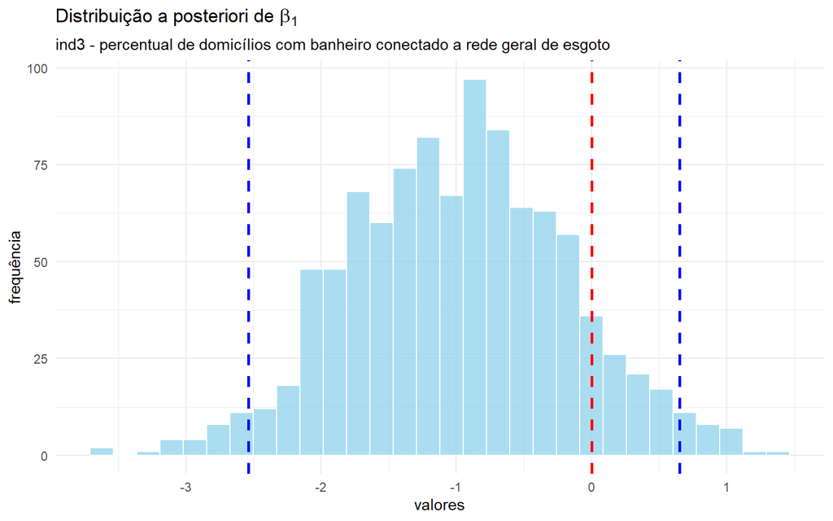

```r
# Gerar amostras da distribuição posterior para o parâmetro ind3
n.amostras <- 1000
posterior_samples <- inla.posterior.sample(n.amostras, modelo_M1)

# Extrair os valores do parâmetro ind3 das amostras
param_index <- 186  # Índice da covariável ind3 (ajustar conforme seu modelo)
ind3_posterior <- sapply(1:1000, function(i) posterior_samples[[i]]$latent[param_index])

# Criar um data frame
df_posterior <- data.frame(ind3_posterior)

# Plotar a curva a posteriori
ggplot(df_posterior, aes(x = ind3_posterior)) +
  geom_histogram(bins = 30, fill = "skyblue", color = "white", alpha = 0.7) +
  geom_vline(xintercept = 0, color = "red", linetype = "dashed", size = 1) +
  geom_vline(xintercept = quantile(ind3_posterior, probs = 0.025),
             color = "blue", linetype = "dashed", size = 1) +
  geom_vline(xintercept = quantile(ind3_posterior, probs = 0.975),
             color = "blue", linetype = "dashed", size = 1) +
  labs(title = expression(paste("Distribuição a posteriori de ", beta[1] )),
       subtitle = "ind3 - percentual de domicílios com banheiro conectado a rede geral de esgoto",
       x = "valores",
       y = "frequência") +
  theme_minimal()
```

```r
tab2 <- exp(quantile(ind3_posterior, probs = c(0.5,0.025,0.975)))
tab2_df <- as.data.frame(t(tab2))
colnames(tab2_df) <- c("Mediana", "2.5%", "97.5%")
rownames(tab2_df) <- "Risco Relativo"

kableExtra::kable(tab2_df, caption = "Tabela: Risco relativo mediano e intervalo de credibilidade de 95%") |>
  kable_styling(bootstrap_options = "striped", full_width = F, position = "center")
```

Tabela: Risco relativo mediano e intervalo de credibilidade de 95%

|  | Mediana | 2.5% | 97.5% |
| --- | --- | --- | --- |
| Risco Relativo | 0.3819182 | 0.0790178 | 1.915103 |

Avaliando o ajuste do modelos, é possível comparar o mapa dos valores observados de casos e a média estimada. Além disso, é possível realizar uma análise do risco relativo dos municípios, identificando aqueles que apresentam risco elevado para dengue, supondo homogeneidade no espaço.

```r
# Extrair e calcular o número médio de casos estimado e o risco relativo
n_areas = nrow(base_modelo)

# Matrizes para armazenar as amostras
casos_est = matrix(NA, ncol = n_areas, nrow = n.amostras)
RR = matrix(NA, ncol = n_areas, nrow = n.amostras)

# Loop para extrair as amostras posteriores
for (i in 1:n.amostras) {
  pred.2a = posterior_samples[[i]]$latent[1:n_areas]
  casos_est[i, ] = exp(pred.2a)  # Casos estimados na escala original
  RR[i, ] = exp(pred.2a) / base_modelo$E  # Risco relativo
}

# Calcular a média posteriori de casos estimados e risco relativo
base_RJ$casos_est_post = colMeans(casos_est)
base_RJ$RR_post = colMeans(RR)
base_RJ$taxa_est = base_RJ$casos_est_post/base_RJ$POP*100000

max(base_RJ$taxa)
```

```
[1] 14332.87
```

```r
max(base_RJ$taxa_est)
```

```
[1] 14319.61
```

```r
# Visualizar as últimas colunas da base
base_RJ[,33:38]
```

```
Simple feature collection with 92 features and 6 fields
Geometry type: MULTIPOLYGON
Dimension:     XY
Bounding box:  xmin: -44.88932 ymin: -23.36893 xmax: -40.95794 ymax: -20.76321
Geodetic CRS:  SIRGAS 2000
# A tibble: 92 × 7
   ind12    POP   taxa casos_est_post RR_post taxa_est                  geometry
   <dbl>  <dbl>  <dbl>          <dbl>   <dbl>    <dbl>        <MULTIPOLYGON [°]>
 1 0.724 179120 8224.          14738.  4.69     8228.  (((-44.51649 -23.03589, …
 2 0.692  11420 2592.            296.  1.48     2594.  (((-42.11437 -21.61204, …
 3 0.718 137773 1379.           1897.  0.785    1377.  (((-42.28399 -22.93928, …
 4 0.684  12236 6628.            811.  3.78     6631.  (((-43.09004 -22.23844, …
 5 0.728  42442  848.            359.  0.482     846.  (((-41.88151 -22.74808, …
 6 0.733  32794 1863.            611.  1.06     1864.  (((-42.03272 -22.97276, …
 7 0.733  98501 2029.           1998.  1.16     2028.  (((-43.82202 -22.51667, …
 8 0.729 181688 1820.           3308.  1.04     1821.  (((-44.19082 -22.63021, …
 9 0.684 518263   33.8           178.  0.0195     34.3 (((-43.3703 -22.69426, -…
10 0.66   29736 9568.           2844.  5.45     9565.  (((-42.40477 -22.27078, …
# ℹ 82 more rows
```

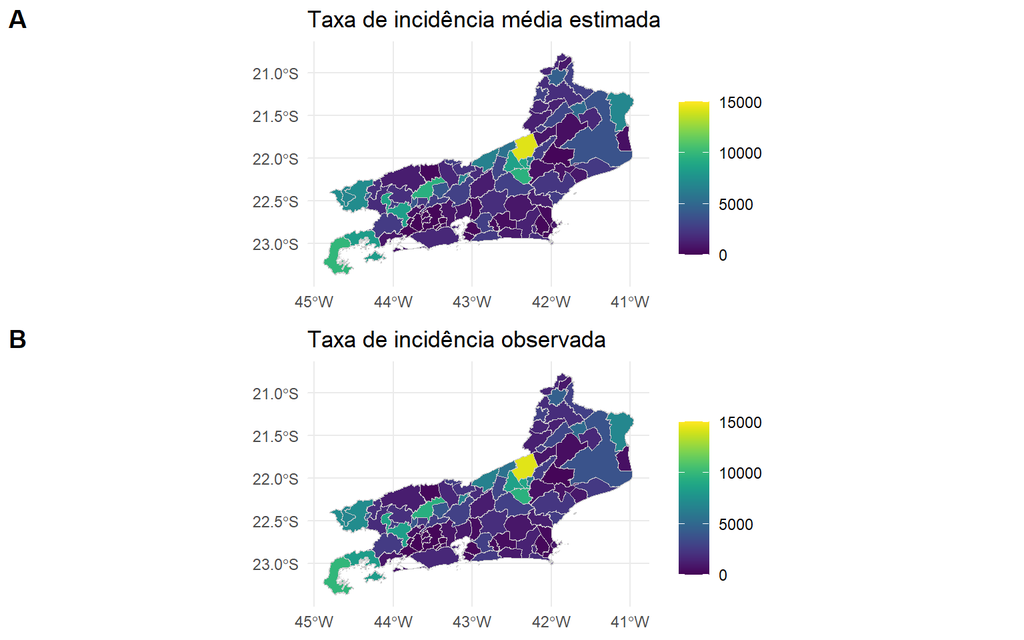

```r
# Mapa dos casos e média estimada
mapa_51 <- ggplot(base_RJ) +
  geom_sf(aes(fill = taxa_est), color = "gray80", size = 0.2) +
  scale_fill_viridis(limits = c(0, 15000)) +
  labs(title = "Taxa de incidência média estimada",
       fill = "") +
  theme_minimal()

mapa_52 <- ggplot(base_RJ) +
  geom_sf(aes(fill = taxa), color = "gray80", size = 0.2) +
  scale_fill_viridis(limits = c(0, 15000)) +
  labs(title = "Taxa de incidência observada",
       fill = "") +
  theme_minimal()

# Organizar as figuras
library(ggpubr)
figura_mapa <- ggarrange(mapa_51, mapa_52,
                         ncol = 1,
                         labels = c("A", "B"))  # Legendas automáticas
# Exibir o resultado
print(figura_mapa)
```

O risco relativo de cada município reflete a probabilidade de ocorrência de casos de dengue em comparação com a média estadual, assumindo uma homogeneidade espacial. Ou seja, municípios com risco relativo maior que 1 têm um risco de dengue superior à média estadual, enquanto municípios com valores menores indicam risco inferior à média. O mapa a seguir apresenta os riscos relativos de cada município.

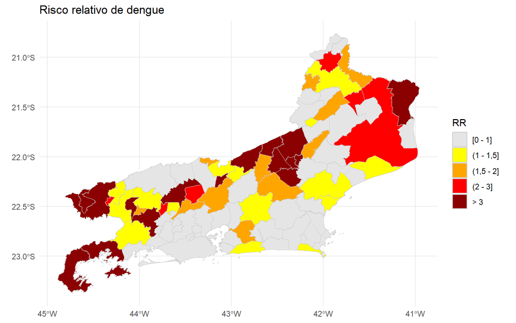

```r
# Criar categorias para risco relativo
base_RJ$risco_cat<- cut(base_RJ$RR_post,
                        breaks = c(-Inf, 1, 1.5, 2, 3,Inf),
                        labels = c("[0 - 1]", "(1 - 1,5]", "(1,5 - 2]", "(2 - 3]", "> 3"))

# Criar o mapa com categorias de risco
mapa_6 <- ggplot(base_RJ) +
  geom_sf(aes(fill = risco_cat), color = "gray80", size = 0.2) +
  scale_fill_manual(values = c("[0 - 1]" = "gray90",
                               "(1 - 1,5]" = "yellow",
                               "(1,5 - 2]" = "orange",
                               "(2 - 3]" = "red",
                               "> 3" = "darkred")) +
  labs(title = "Risco relativo de dengue",
       fill = "RR") +
  theme_minimal()

# Exibir o mapa
mapa_6
```